# Peer graded Assignment: Course Project 1

Hisrael Passarelli

05/05/2020

### **Introduction**

It is now possible to collect a large amount of data about personal movement using activity monitoring devices such as a Fitbit, Nike Fuelband, or Jawbone Up. These type of devices are part of the “quantified self” movement – a group of enthusiasts who take measurements about themselves regularly to improve their health, to find patterns in their behavior, or because they are tech geeks. But these data remain under-utilized both because the raw data are hard to obtain and there is a lack of statistical methods and software for processing and interpreting the data.

This assignment makes use of data from a personal activity monitoring device. This device collects data at 5 minute intervals through out the day. The data consists of two months of data from an anonymous individual collected during the months of October and November, 2012 and include the number of steps taken in 5 minute intervals each day.

The data for this assignment can be downloaded from the course web site:

Dataset: Activity monitoring data [52K] The variables included in this dataset are:

- **steps**: Number of steps taking in a 5-minute interval (missing values are coded as NA);
- **date**: The date on which the measurement was taken in YYYY-MM-DD format;
- **interval**: Identifier for the 5-minute interval in which measurement was taken;

The dataset is stored in a comma-separated-value (CSV) file and there are a total of 17,568 observations in this dataset.

#### **What is mean total number of steps taken per day?**

For this part of the assignment, I am ignoring the missing values in the dataset.

##### **1. Calculate the total number of steps taken per day.**

```r
stepsbyday <- aggregate(steps ~ date, data=activity, FUN=sum)
```

##### **2. Make a histogram of the total number of steps taken each day**

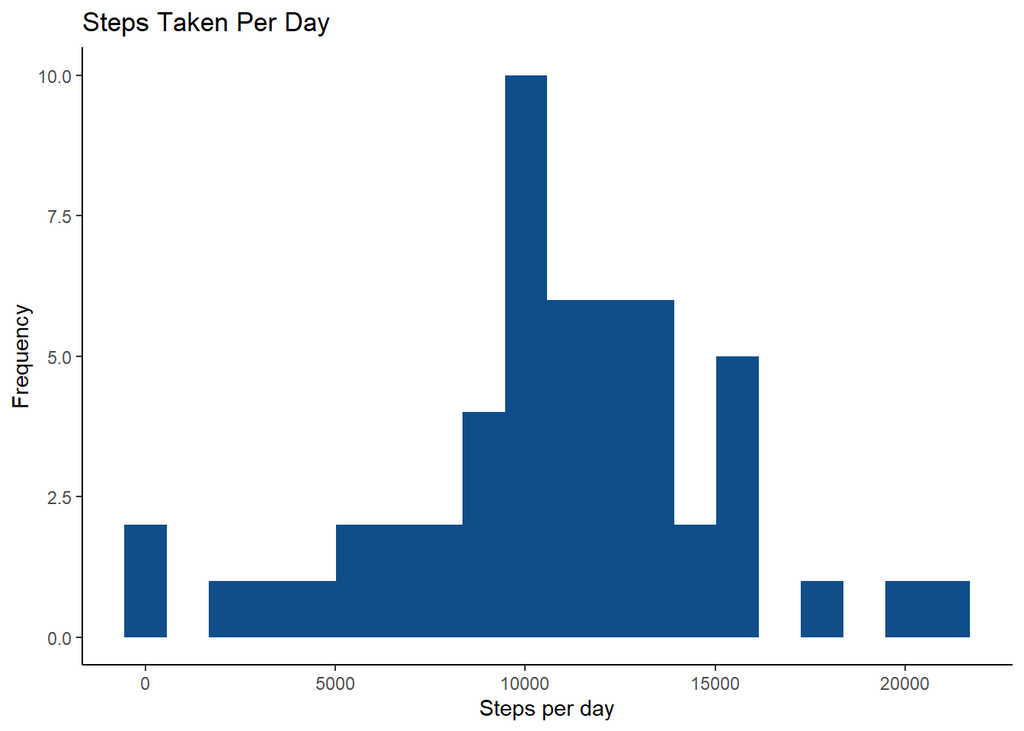

```r
g1<- ggplot(data=stepsbyday, aes(x=steps))+
        geom_histogram(bins=20,
                       fill="dodgerblue4")+
        theme_classic()+
        xlab("Steps per day")+
        ylab("Frequency")+
        labs(title = "Steps Taken Per Day")
g1
```

##### **3. Calculate and report the mean and median of the total number of steps taken per day**

```r
mean(stepsbyday$steps)
```

```
## [1] 10766.19
```

```r
median(stepsbyday$steps)
```

```
## [1] 10765
```

The mean of the total number of steps taken per day is 10,766. The median result is close to that observed in the mean: 10,765 steps per day.

#### **What is the average daily activity pattern?**

##### **1. Make a time series plot (i.e. type=“l”) of the 5-minute interval (x-axis) and the average number of steps taken, averaged across all days (y-axis)**

```r
steps_interval <- aggregate(steps ~ interval, data=activity, FUN= mean, na.rm=TRUE)

head(steps_interval)
```

```
##   interval     steps
## 1        0 1.7169811
## 2        5 0.3396226
## 3       10 0.1320755
## 4       15 0.1509434
## 5       20 0.0754717
## 6       25 2.0943396
```

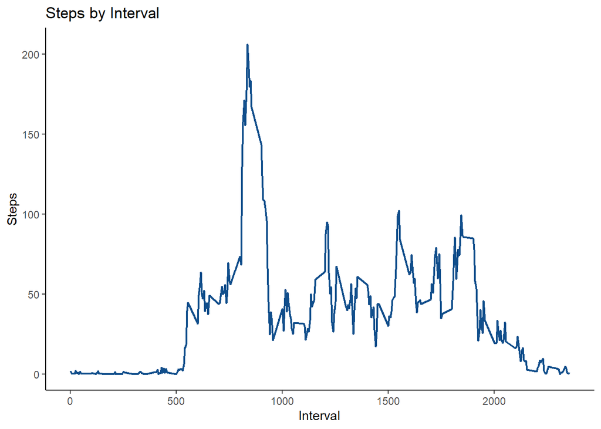

```r
ggplot(data=steps_interval, aes(x=interval, y=steps))+
        geom_line(color="dodgerblue4", size=.8)+
        labs(x="Interval", y="Steps", title= "Steps by Interval")+
        theme_classic()
```

##### **2. Which 5-minute interval, on average across all the days in the dataset, contains the maximum number of steps?**

```r
steps_interval[which.max(steps_interval$steps),]
```

```
##     interval    steps
## 104      835 206.1698
```

#### **Imputing missing values**

Note that there are a number of days/intervals where there are missing values (coded as NA). The presence of missing days may introduce bias into some calculations or summaries of the data.

##### **1. Calculate and report the total number of missing values in the dataset (i.e. the total number of rows with NAs)**

```r
sum(is.na(activity))
```

```
## [1] 2304
```

##### **3. Create a new dataset that is equal to the original dataset but with the missing data filled in.**.

```r
activity2 <- activity

activity2$steps[is.na(activity2$steps)] <- mean(activity2$steps, na.rm = TRUE)

stepsbyday2 <- aggregate(steps ~ date, data=activity2, FUN=sum)
```

#### **4.Make a histogram of the total number of steps taken each day and Calculate and report the mean and median total number of steps taken per day. Do these values differ from the estimates from the first part of the assignment? What is the impact of imputing missing data on the estimates of the total daily number of steps?**

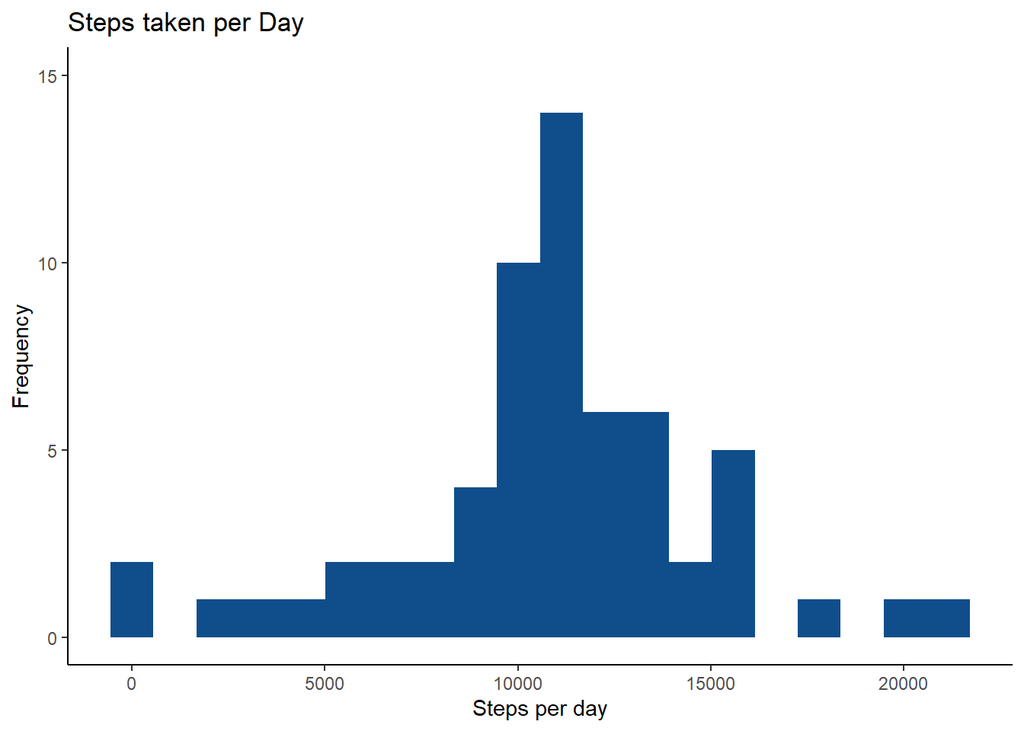

```r
g2<- ggplot(data=stepsbyday2, aes(x=steps))+
        geom_histogram(bins=20,
                       fill="dodgerblue4")+
        theme_classic()+
        xlab("Steps per day")+
        ylab("Frequency")+
        ylim(0,15)+
        labs(title = "Steps taken per Day")
g2
```

In order to analyze differences between both histograms I reproduced a new histogram with the same data of the first plot, but with the same scale limits in y-axis. This procedure avoids misleading interpretations about the data and allows to compare two cases side by side.

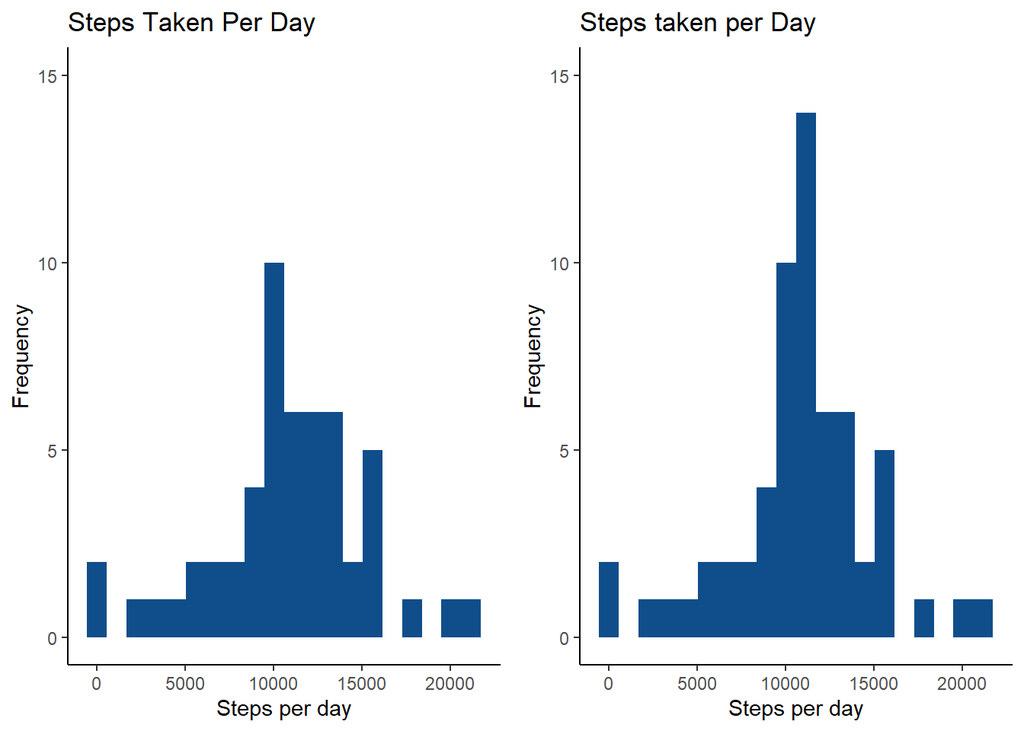

```r
#GridExtra Package
g1_New<- ggplot(data=stepsbyday, aes(x=steps))+
        geom_histogram(bins=20,
                       fill="dodgerblue4")+
        theme_classic()+
        xlab("Steps per day")+
        ylim(0,15)+
        ylab("Frequency")+
        labs(title = "Steps Taken Per Day")

grid.arrange(g1_New,g2, ncol=2)
```

```r
mean(stepsbyday2$steps)
```

```
## [1] 10766.19
```

```r
median(stepsbyday2$steps)
```

```
## [1] 10766.19
```

#### **Are there differences in activity patterns between weekdays and weekends?**

#### **1. Create a new factor variable in the dataset with two levels – “weekday” and “weekend” indicating whether a given date is a weekday or weekend day.**

In this stage I created a new vector of weekdays. Unfortunately, I have not succeeded in changing the default language from Portuguese to English yet. If you run this chunk, modify the *weekdays1* vector content for the corresponding weekdays (Monday, Tuesday, Wednesday, Thursday and Friday) in your R language.

```r
activity$date <- as.Date(activity$date)

#create a vector of weekdays
weekdays1 <- as.factor(c('segunda-feira', 'terça-feira', 'quarta-feira', 'quinta-feira', 'sexta-feira'))

#Use `%in%` and `weekdays` to create a logical vector
#convert to `factor` and specify the `levels/labels`

activity$wDay <-factor((weekdays(activity$date) %in% weekdays1),
         levels=c(FALSE, TRUE), labels=c('weekend', 'weekday'))
newdata <- aggregate(steps ~ interval + wDay, data=activity, FUN = mean)
table(newdata$wDay)
```

```
##
## weekend weekday
##     288     288
```

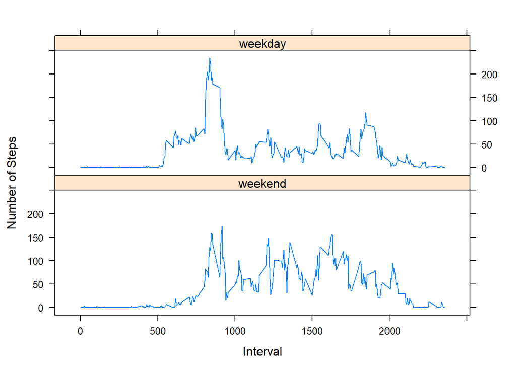

```r
xyplot(steps ~ interval | factor(wDay),
        data=newdata,
        type="l",
        layout=c(1,2),
        xlab = "Interval",
        ylab = "Number of Steps")
```